# ggplot2 : 9. Facets

```r
# install.packages(c('ggplot2’, 'gcookbook’), dependencies = TRUE)
library(ggplot2)
library(gcookbook)
```

## Splitting Data into Subplots with Facets

```r
str(mpg)
```

```
## tibble [234 × 11] (S3: tbl_df/tbl/data.frame)
##  $ manufacturer: chr [1:234] "audi" "audi" "audi" "audi" ...
##  $ model       : chr [1:234] "a4" "a4" "a4" "a4" ...
##  $ displ       : num [1:234] 1.8 1.8 2 2 2.8 2.8 3.1 1.8 1.8 2 ...
##  $ year        : int [1:234] 1999 1999 2008 2008 1999 1999 2008 1999 1999 2008 ...
##  $ cyl         : int [1:234] 4 4 4 4 6 6 6 4 4 4 ...
##  $ trans       : chr [1:234] "auto(l5)" "manual(m5)" "manual(m6)" "auto(av)" ...
##  $ drv         : chr [1:234] "f" "f" "f" "f" ...
##  $ cty         : int [1:234] 18 21 20 21 16 18 18 18 16 20 ...
##  $ hwy         : int [1:234] 29 29 31 30 26 26 27 26 25 28 ...
##  $ fl          : chr [1:234] "p" "p" "p" "p" ...
##  $ class       : chr [1:234] "compact" "compact" "compact" "compact" ...
```

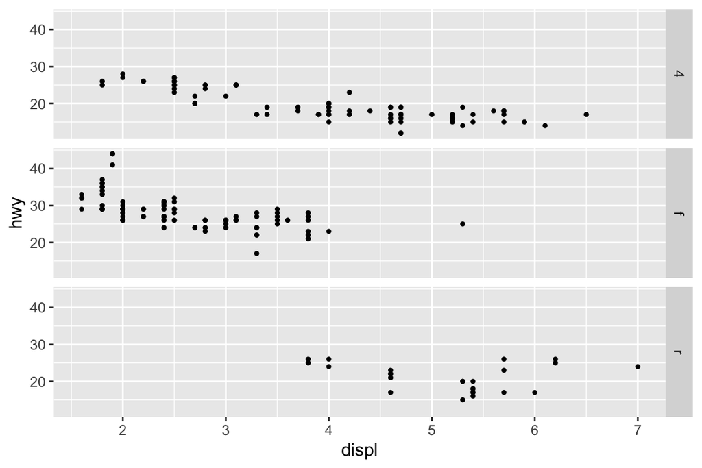

```r
p <- ggplot(mpg, aes(x = displ, y = hwy)) + geom_point(size = 0.8)
# faceted by drv, in vertically arranged subpanels
p + facet_grid(drv ~ .)
```

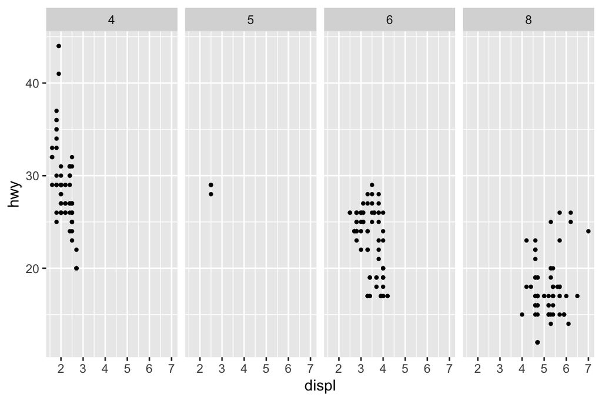

```r
# faceted by cyl, in horizontally arranged subpanels
p + facet_grid(. ~ cyl)
```

- x축에 변수 displ, y축에 변수 hwy로 하는 산점도를 그리되, `facet_grid()` 에 적용된 변수의 레벨별로 그림.
- `facet_grid(drv ~ .)` : facet을 drv 변수 수준별로 세로로 놓이게 함.
- `facet_grid(. ~ cyl)` : facet을 cyl 변수 수준별로 가로로 놓이게 함.
- 각 facet의 가로, 세로축의 스케일이 동일함에 유의할 것.

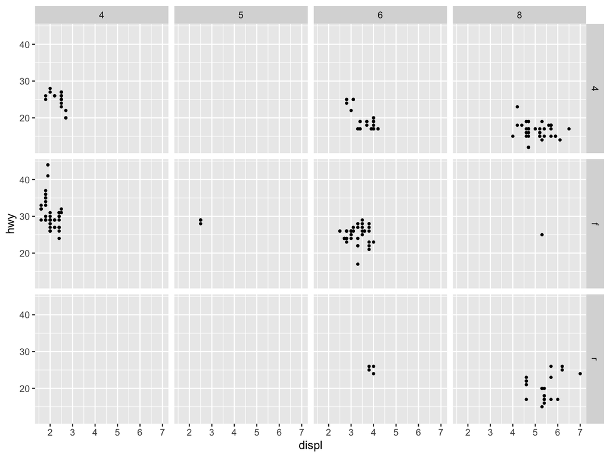

```r
p <- ggplot(mpg, aes(x = displ, y = hwy)) + geom_point(size = 0.8)
p + facet_grid(drv ~ cyl)
```

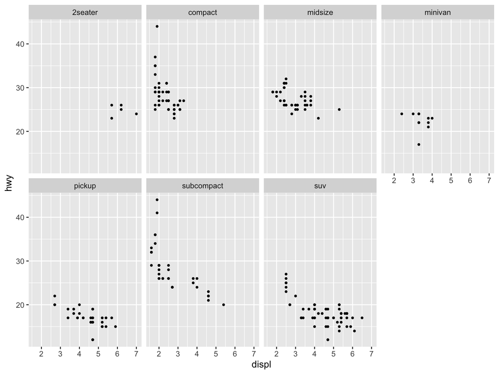

```r
p <- ggplot(mpg, aes(x = displ, y = hwy)) + geom_point(size = 0.8)
p + facet_wrap(~ class, nrow = 2)
```

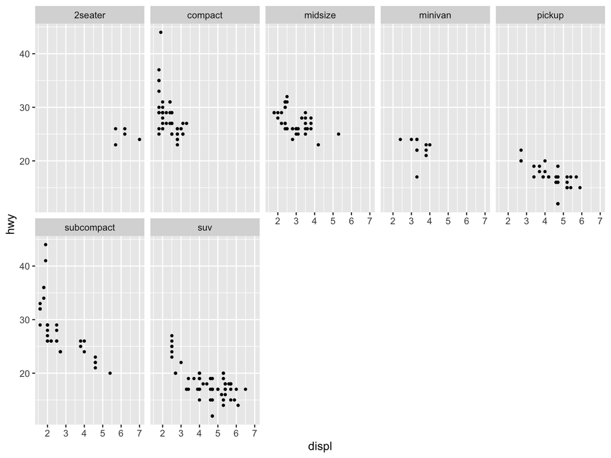

```r
p + facet_wrap(~ class, ncol = 5)
```

- `facet_wrap(~ class, nrow = 2)` : displ 과 hwy 간의 산점도를 그리되 class 변수의 수준별로 그림. 배치는 2행이 되도록 함.
- `facet_wrap(~ class, ncol = 5)` : displ 과 hwy 간의 산점도를 그리되 class 변수의 수준별로 그림. 배치는 5열이 되도록 함.
- `facet_wrap()`에서 ~ 앞에 . 이 없음에 유의.

## Using Facts with Different Axes

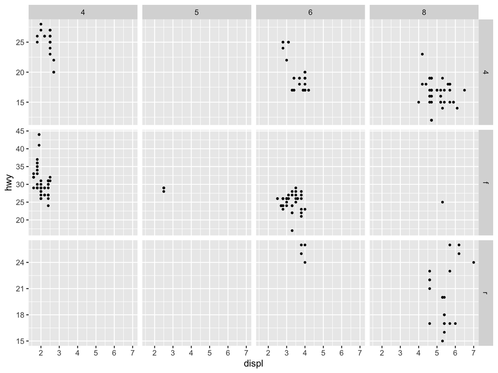

```r
p <- ggplot(mpg, aes(x = displ, y = hwy)) + geom_point(size = 0.8)
p + facet_grid(drv ~ cyl, scales = 'free_y')
```

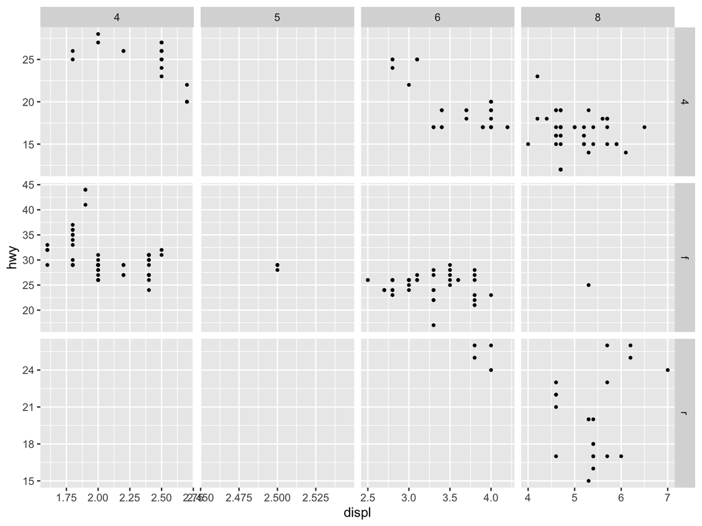

```r
p + facet_grid(drv ~ cyl, scales = 'free')
```

- `scales = ‘free_y’` : facet들의 세로축의 스케일을 다르게 함. 하지만 같은 행에 속한 facet은 같은 세로축 스케일을 가짐.
- `scales = ‘free’` : facet에 쓰인 가로, 세로 변수의 스케일을 각기 다르게 함. 하지만 같은 행에 놓인 facet은 같은 세로 스케일을 가지고, 같은 열에 놓인 facet은 같은 가로 스케일을 가짐.

## Changing the Text of Facet Labels

```r
mpg2 <- mpg
levels(mpg2$drv)
```

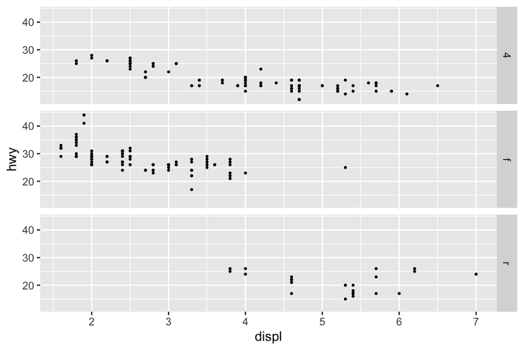

```r
levels(mpg2$drv) <- c('4wd', 'Front', 'Rear')
ggplot(mpg2, aes(x = displ, y = hwy)) + geom_point(size = 0.5) + facet_grid(drv ~ .)
```

## Changing the Appearance of Facet Labels

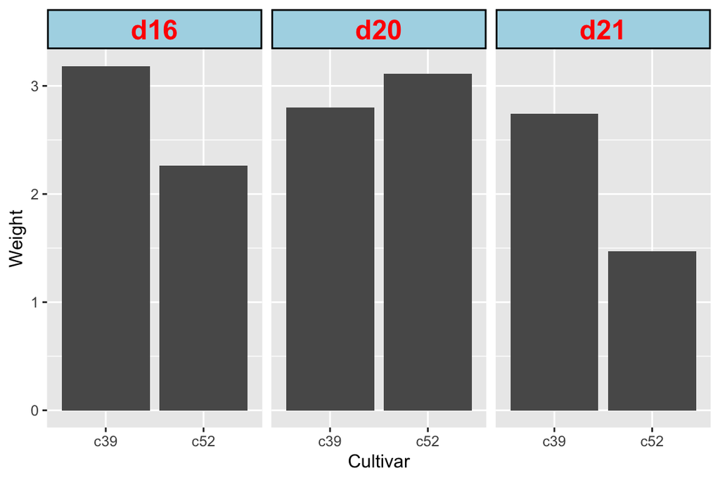

```r
ggplot(cabbage_exp, aes(x = Cultivar, y = Weight)) +
  geom_col() +
  facet_grid(. ~ Date) +
  theme(strip.text = element_text(face = 'bold', size = rel(1.5), color = 'red'),
        strip.background = element_rect(fill = 'lightblue', color = 'black', size = 1))
```

- facet label의 모양을 바꾸는 예제.